# hw1

saxena

2023-09-20

Activity 1

```
#installing packages
install.packages("tidyverse", dependencies = TRUE, INSTALL_opts = '--no-lock')
inst.packages <- installed.packages()[,1]
all(is.element(c("tidyverse", "arules" , "caret", "markdown", "reticulate"),
               inst.packages))
```

Activity 2

```r
#Read the file adult.data containing the training data into the variable ‘adult’.
setwd("C:/Users/Raj/Downloads/Machine Learning and Data Mining/Lab Assignments/Dataset for Homework 1/Adult")
adult <- read.table("adult.data", header = FALSE, sep = "\t", na = c('?'))

#Printing 'adult' to be sure the dataset has been read correctly
#adult
print(head(adult, 10))
```

```
##                                                                                                                                       V1
## 1        39, State-gov, 77516, Bachelors, 13, Never-married, Adm-clerical, Not-in-family, White, Male, 2174, 0, 40, United-States, <=50K
## 2  50, Self-emp-not-inc, 83311, Bachelors, 13, Married-civ-spouse, Exec-managerial, Husband, White, Male, 0, 0, 13, United-States, <=50K
## 3               38, Private, 215646, HS-grad, 9, Divorced, Handlers-cleaners, Not-in-family, White, Male, 0, 0, 40, United-States, <=50K
## 4              53, Private, 234721, 11th, 7, Married-civ-spouse, Handlers-cleaners, Husband, Black, Male, 0, 0, 40, United-States, <=50K
## 5                     28, Private, 338409, Bachelors, 13, Married-civ-spouse, Prof-specialty, Wife, Black, Female, 0, 0, 40, Cuba, <=50K
## 6             37, Private, 284582, Masters, 14, Married-civ-spouse, Exec-managerial, Wife, White, Female, 0, 0, 40, United-States, <=50K
## 7              49, Private, 160187, 9th, 5, Married-spouse-absent, Other-service, Not-in-family, Black, Female, 0, 0, 16, Jamaica, <=50K
## 8     52, Self-emp-not-inc, 209642, HS-grad, 9, Married-civ-spouse, Exec-managerial, Husband, White, Male, 0, 0, 45, United-States, >50K
## 9        31, Private, 45781, Masters, 14, Never-married, Prof-specialty, Not-in-family, White, Female, 14084, 0, 50, United-States, >50K
## 10       42, Private, 159449, Bachelors, 13, Married-civ-spouse, Exec-managerial, Husband, White, Male, 5178, 0, 40, United-States, >50K
```

```r
#installing readr
#install.packages("readr")
library(readr)

#Reading adult
setwd("C:/Users/Raj/Downloads/Machine Learning and Data Mining/Lab Assignments/Dataset for Homework 1/Adult")
adult <- read.table("adult.data", header = FALSE, sep = "\t", na = c('?'))
adult1 <- read_csv('adult.data', col_names = FALSE, trim_ws = TRUE, na = c("?"))
#Printing a row with missing data using R
row_with_missing_data <- adult1[which(rowSums(is.na(adult1)) > 0), , drop = TRUE]

head(row_with_missing_data, 1)
```

```
## # A tibble: 1 × 15
##      X1 X2        X3 X4       X5 X6    X7    X8    X9    X10     X11   X12   X13
##   <dbl> <chr>  <dbl> <chr> <dbl> <chr> <chr> <chr> <chr> <chr> <dbl> <dbl> <dbl>
## 1    40 Priv… 121772 Asso…    11 Marr… Craf… Husb… Asia… Male      0     0    40
## # ℹ 2 more variables: X14 <chr>, X15 <chr>
```

```r
#Reading the dataset and assigning column names
library (readr)
setwd("C:/Users/Raj/Downloads/Machine Learning and Data Mining/Lab Assignments/Dataset for Homework 1/Adult")
adult <- read.table("adult.data", header = FALSE, sep = "\t", na = c('?'))
custom_column_names <- c('age', 'workclass', 'fnlwgt', 'education','education_num','marital_status','occupation','relationship', 'race', 'sex', 'capital_gain', 'capital_loss','hours_per_week', 'native_country', 'sal_range')
adult <- read_csv('adult.data', col_names = custom_column_names)
#Printing the dataset to verify the change
#adult
head(adult, 5)
```

```
## # A tibble: 5 × 15
##     age workclass       fnlwgt education education_num marital_status occupation
##   <dbl> <chr>            <dbl> <chr>             <dbl> <chr>          <chr>
## 1    39 State-gov        77516 Bachelors            13 Never-married  Adm-cleri…
## 2    50 Self-emp-not-i…  83311 Bachelors            13 Married-civ-s… Exec-mana…
## 3    38 Private         215646 HS-grad               9 Divorced       Handlers-…
## 4    53 Private         234721 11th                  7 Married-civ-s… Handlers-…
## 5    28 Private         338409 Bachelors            13 Married-civ-s… Prof-spec…
## # ℹ 8 more variables: relationship <chr>, race <chr>, sex <chr>,
## #   capital_gain <dbl>, capital_loss <dbl>, hours_per_week <dbl>,
## #   native_country <chr>, sal_range <chr>
```

```r
# Converting attributes to factors
library (readr)
setwd("C:/Users/Raj/Downloads/Machine Learning and Data Mining/Lab Assignments/Dataset for Homework 1/Adult")
adult <- read.table("adult.data", header = FALSE, sep = "\t", na = c('?'))
custom_column_names <- c('age', 'workclass', 'fnlwgt', 'education','education_num','marital_status','occupation','relationship', 'race', 'sex', 'capital_gain', 'capital_loss','hours_per_week', 'native_country', 'sal_range')
adult <- read_csv('adult.data', col_names = custom_column_names)
adult$workclass <- as.factor(adult$workclass)
adult$education <- as.factor(adult$education)
adult$marital_status <- as.factor(adult$marital_status)
adult$occupation <- as.factor(adult$occupation)
adult$relationship <- as.factor(adult$relationship)
adult$race <- as.factor(adult$race)
adult$sex <- as.factor(adult$sex)
adult$native_country <- as.factor(adult$native_country)
adult$sal_range <- as.factor(adult$sal_range)

# Printing the updated data frame to verify the change
#print(adult)
head(adult, 5)
```

```
## # A tibble: 5 × 15
##     age workclass       fnlwgt education education_num marital_status occupation
##   <dbl> <fct>            <dbl> <fct>             <dbl> <fct>          <fct>
## 1    39 State-gov        77516 Bachelors            13 Never-married  Adm-cleri…
## 2    50 Self-emp-not-i…  83311 Bachelors            13 Married-civ-s… Exec-mana…
## 3    38 Private         215646 HS-grad               9 Divorced       Handlers-…
## 4    53 Private         234721 11th                  7 Married-civ-s… Handlers-…
## 5    28 Private         338409 Bachelors            13 Married-civ-s… Prof-spec…
## # ℹ 8 more variables: relationship <fct>, race <fct>, sex <fct>,
## #   capital_gain <dbl>, capital_loss <dbl>, hours_per_week <dbl>,
## #   native_country <fct>, sal_range <fct>
```

Activity 3

```r
#Calculating Standard Deviation without using DPlyr library
custom_sd <- function(x) {
  n <- length(x)

  if (n <= 1) {
    # Returning NA for vectors with 0 or 1 element
    return(NA)
  }

  mean_x <- mean(x)
  sum_squared_diff <- sum((x - mean_x)^2)

  # Calculating the sample standard deviation
  sample_sd <- sqrt(sum_squared_diff / (n - 1))

  return(sample_sd)
}

# Example usage:
vector <- c(4, 4, 4, 4, 4, 4, 4, 4)
result <- custom_sd(vector)
print(result)
```

```
## [1] 0
```

```r
vector <- c(4, 5, 6, 19, 51, 2, 14, 41)
result <- custom_sd(vector)
print(result)
```

```
## [1] 18.51447
```

```r
#Finding Standard Deviation of ages in the adult dataset
library (readr)
setwd("C:/Users/Raj/Downloads/Machine Learning and Data Mining/Lab Assignments/Dataset for Homework 1/Adult")
adult <- read.table("adult.data", header = FALSE, sep = "\t", na = c('?'))
custom_column_names <- c('age', 'workclass', 'fnlwgt', 'education','education_num','marital_status','occupation','relationship', 'race', 'sex', 'capital_gain', 'capital_loss','hours_per_week', 'native_country')
adult <- read_csv('adult.data', col_names = c('age', 'workclass', 'fnlwgt', 'education','education_num','marital_status','occupation','relationship', 'race', 'sex', 'capital_gain', 'capital_loss','hours_per_week', 'native_country'), na = c('?', 'NA'))
age_sd <- custom_sd(adult$age)

# Printing the result
cat("Standard Deviation of Ages:", age_sd, "\n")
```

```
## Standard Deviation of Ages: 13.64043
```

```r
#Creating a matrix  having as its first column all 1s and as its second column the column of the #ages in the adult dataset
library (readr)
setwd("C:/Users/Raj/Downloads/Machine Learning and Data Mining/Lab Assignments/Dataset for Homework 1/Adult")
adult <- read.table("adult.data", header = FALSE, sep = "\t", na = c('?'))
custom_column_names <- c('age', 'workclass', 'fnlwgt', 'education','education_num','marital_status','occupation','relationship', 'race', 'sex', 'capital_gain', 'capital_loss','hours_per_week', 'native_country', 'sal_range')
adult <- read_csv('adult.data', col_names = custom_column_names)
H <- cbind(1, adult$age)
#print (H)

#Write and execute the command to find the transpose of the matrix H, and to multiply the transpose with the original and print the result
print (t(H) %*% H)
```

```
##         [,1]     [,2]
## [1,]   32561  1256257
## [2,] 1256257 54526623
```

```r
#Write and execute the command to find the inverse of the matrix Ht x H
solve(t(H) %*% H)
```

```
##               [,1]          [,2]
## [1,]  2.764205e-04 -6.368543e-06
## [2,] -6.368543e-06  1.650666e-07
```

```r
#Write and execute the command to verify that the matrix thus found is indeed the inverse of Ht x H
K <- round((solve(t(H) %*% H)) %*% (t(H) %*% H))
print (K)
```

```
##      [,1] [,2]
## [1,]    1    0
## [2,]    0    1
```

```r
#Reading adult
library (readr)
setwd("C:/Users/Raj/Downloads/Machine Learning and Data Mining/Lab Assignments/Dataset for Homework 1/Adult")
adult <- read.table("adult.data", header = FALSE, sep = "\t", na = c('?'))
custom_column_names <- c('age', 'workclass', 'fnlwgt', 'education','education_num','marital_status','occupation','relationship', 'race', 'sex', 'capital_gain', 'capital_loss','hours_per_week', 'native_country', 'sal_range')
adult <- read_csv('adult.data', col_names = custom_column_names)
```

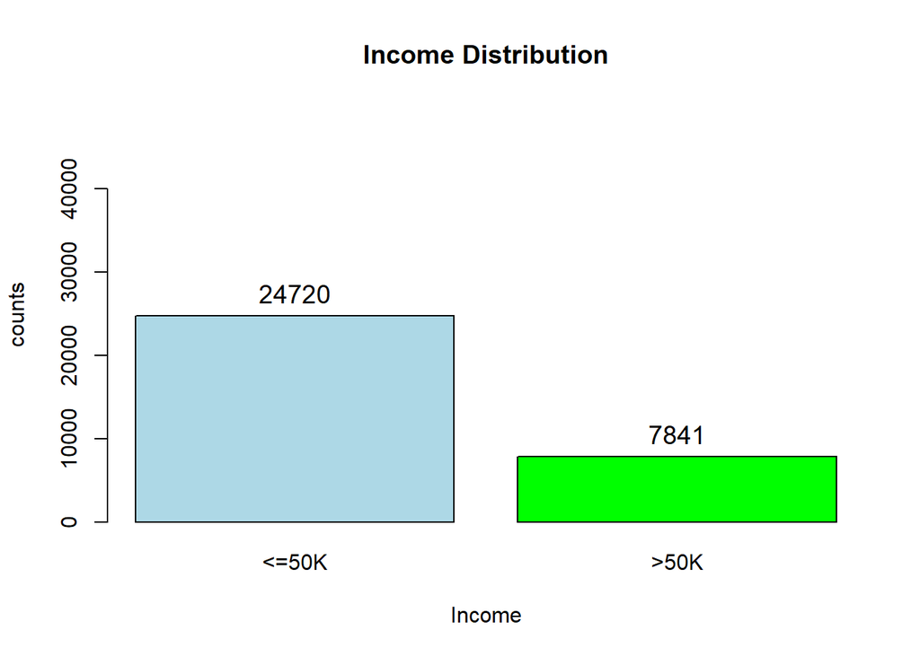

```r
response <- adult[, 15]
#print(response)
# Calculate the counts for each category
cnts <- table(response)
#print(cnts)
# Create a bar plot
#barplot(cnts,
        #main = "Income Distribution",
        #xlab = "Income",
        #ylab = "counts",
        #col = c("lightblue", "green"),
        #names.arg = c("<=50K", ">50K"),
        #ylim = c(0, max(cnts) + 100000))

# Add counts above the bars
text(x = barplot(cnts,
        main = "Income Distribution",
        xlab = "Income",
        ylab = "counts",
        col = c("lightblue", "green"),
        names.arg = c("<=50K", ">50K"),
        ylim = c(0, max(cnts) + 25000)), y = cnts, labels = cnts, pos = 3, cex = 1.2)
```

```r
#installing ggplot
#install.packages("ggplot2")

#Reading adult
library (readr)
setwd("C:/Users/Raj/Downloads/Machine Learning and Data Mining/Lab Assignments/Dataset for Homework 1/Adult")
adult <- read.table("adult.data", header = FALSE, sep = "\t", na = c('?'))
custom_column_names <- c('age', 'workclass', 'fnlwgt', 'education','education_num','marital_status','occupation','relationship', 'race', 'sex', 'capital_gain', 'capital_loss','hours_per_week', 'native_country', 'sal_range')
adult <- read_csv('adult.data', col_names = custom_column_names)
#Creating a bar plot using ggplot
library (ggplot2)
response <- adult[, 15]
cnts <- table(response)
print(cnts)
```

```
## sal_range
## <=50K  >50K
## 24720  7841
```

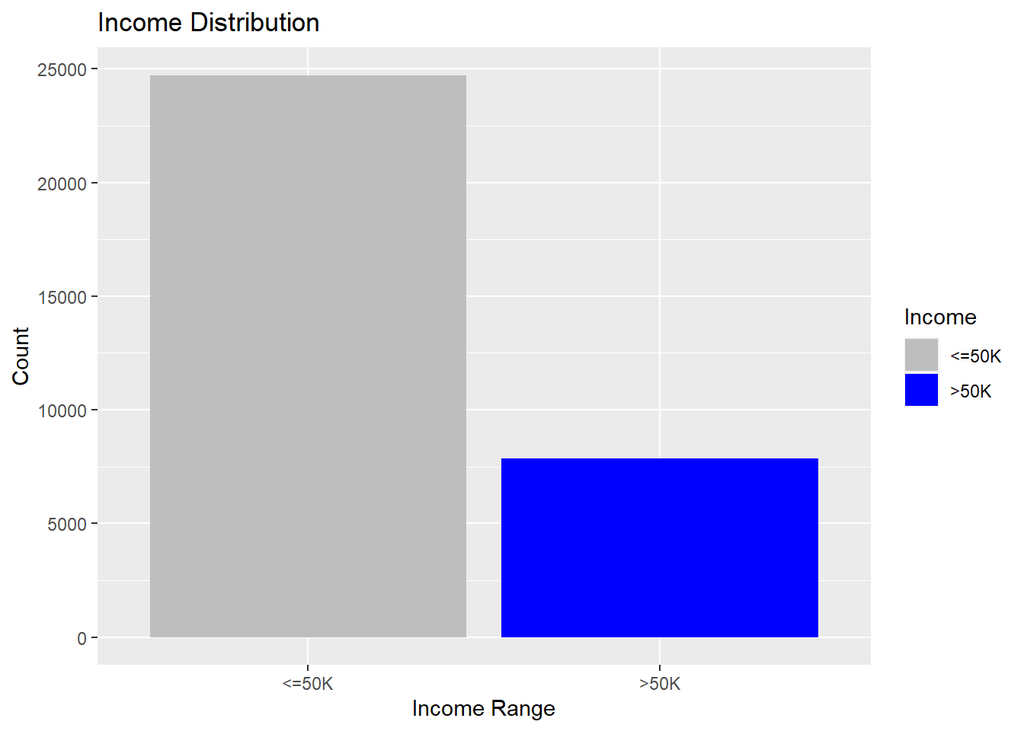

```r
dataframe <- data.frame(Income = names(cnts), Count = as.numeric(cnts))
ggplot(dataframe, aes(x = Income, y = Count, fill = Income)) +
  geom_bar(stat = "identity") +
  labs(
    title = "Income Distribution",
    x = "Income Range",
    y = "Count"
  ) +
  scale_fill_manual(values = c("<=50K" = "grey", ">50K" = "blue"))
```

```r
#Replacing cells with Never-worked as their values with cells having unemployed as their values
start_row <- 5360
end_row <- 5369
print(adult[start_row:end_row, ])
```

```
## # A tibble: 10 × 15
##      age workclass      fnlwgt education education_num marital_status occupation
##    <dbl> <chr>           <dbl> <chr>             <dbl> <chr>          <chr>
##  1    54 Private        138845 Some-col…            10 Never-married  Other-ser…
##  2    19 Local-gov      169853 HS-grad               9 Never-married  Craft-rep…
##  3    18 Never-worked   206359 10th                  6 Never-married  ?
##  4    60 Private        224097 HS-grad               9 Married-civ-s… Craft-rep…
##  5    28 Self-emp-not-… 160786 HS-grad               9 Never-married  Craft-rep…
##  6    43 Self-emp-not-… 190044 HS-grad               9 Married-civ-s… Sales
##  7    49 Local-gov      145290 5th-6th               3 Married-civ-s… Other-ser…
##  8    25 Private        120268 Bachelors            13 Never-married  Prof-spec…
##  9    17 Private        327434 10th                  6 Never-married  Sales
## 10    41 Self-emp-inc   218302 Bachelors            13 Married-civ-s… Sales
## # ℹ 8 more variables: relationship <chr>, race <chr>, sex <chr>,
## #   capital_gain <dbl>, capital_loss <dbl>, hours_per_week <dbl>,
## #   native_country <chr>, sal_range <chr>
```

```r
adult$workclass[adult$workclass == "Never-worked"] <- "Unemployed"
start_row <- 5360
end_row <- 5369


print(adult[start_row:end_row, ])
```

```
## # A tibble: 10 × 15
##      age workclass      fnlwgt education education_num marital_status occupation
##    <dbl> <chr>           <dbl> <chr>             <dbl> <chr>          <chr>
##  1    54 Private        138845 Some-col…            10 Never-married  Other-ser…
##  2    19 Local-gov      169853 HS-grad               9 Never-married  Craft-rep…
##  3    18 Unemployed     206359 10th                  6 Never-married  ?
##  4    60 Private        224097 HS-grad               9 Married-civ-s… Craft-rep…
##  5    28 Self-emp-not-… 160786 HS-grad               9 Never-married  Craft-rep…
##  6    43 Self-emp-not-… 190044 HS-grad               9 Married-civ-s… Sales
##  7    49 Local-gov      145290 5th-6th               3 Married-civ-s… Other-ser…
##  8    25 Private        120268 Bachelors            13 Never-married  Prof-spec…
##  9    17 Private        327434 10th                  6 Never-married  Sales
## 10    41 Self-emp-inc   218302 Bachelors            13 Married-civ-s… Sales
## # ℹ 8 more variables: relationship <chr>, race <chr>, sex <chr>,
## #   capital_gain <dbl>, capital_loss <dbl>, hours_per_week <dbl>,
## #   native_country <chr>, sal_range <chr>
```

```r
#Using dplyr to do the same
library(dplyr)
library (readr)
setwd("C:/Users/Raj/Downloads/Machine Learning and Data Mining/Lab Assignments/Dataset for Homework 1/Adult")
adult <- read.table("adult.data", header = FALSE, sep = "\t", na = c('?'))
custom_column_names <- c('age', 'workclass', 'fnlwgt', 'education','education_num','marital_status','occupation','relationship', 'race', 'sex', 'capital_gain', 'capital_loss','hours_per_week', 'native_country', 'sal_range')
adult <- read_csv('adult.data', col_names = custom_column_names)
adult <- adult %>%
  mutate(workclass = ifelse(workclass == "Never-worked", "Unemployed", workclass))
head (adult, 1000)
```

```
## # A tibble: 1,000 × 15
##      age workclass      fnlwgt education education_num marital_status occupation
##    <dbl> <chr>           <dbl> <chr>             <dbl> <chr>          <chr>
##  1    39 State-gov       77516 Bachelors            13 Never-married  Adm-cleri…
##  2    50 Self-emp-not-…  83311 Bachelors            13 Married-civ-s… Exec-mana…
##  3    38 Private        215646 HS-grad               9 Divorced       Handlers-…
##  4    53 Private        234721 11th                  7 Married-civ-s… Handlers-…
##  5    28 Private        338409 Bachelors            13 Married-civ-s… Prof-spec…
##  6    37 Private        284582 Masters              14 Married-civ-s… Exec-mana…
##  7    49 Private        160187 9th                   5 Married-spous… Other-ser…
##  8    52 Self-emp-not-… 209642 HS-grad               9 Married-civ-s… Exec-mana…
##  9    31 Private         45781 Masters              14 Never-married  Prof-spec…
## 10    42 Private        159449 Bachelors            13 Married-civ-s… Exec-mana…
## # ℹ 990 more rows
## # ℹ 8 more variables: relationship <chr>, race <chr>, sex <chr>,
## #   capital_gain <dbl>, capital_loss <dbl>, hours_per_week <dbl>,
## #   native_country <chr>, sal_range <chr>
```

Activity 4

```r
#Reading adult
library (readr)
setwd("C:/Users/Raj/Downloads/Machine Learning and Data Mining/Lab Assignments/Dataset for Homework 1/Adult")
adult <- read.table("adult.data", header = FALSE, sep = "\t", na = c('?'))
custom_column_names <- c('age', 'workclass', 'fnlwgt', 'education','education_num','marital_status','occupation','relationship', 'race', 'sex', 'capital_gain', 'capital_loss','hours_per_week', 'native_country', 'sal_range')
adult <- read_csv('adult.data', col_names = custom_column_names)
#Filtering rows using dplyr
library(dplyr)

selected_rows <- adult %>%  filter(`marital_status` == "Never-married" & age < 45)
head(selected_rows, 5)
```

```
## # A tibble: 5 × 15
##     age workclass       fnlwgt education education_num marital_status occupation
##   <dbl> <chr>            <dbl> <chr>             <dbl> <chr>          <chr>
## 1    39 State-gov        77516 Bachelors            13 Never-married  Adm-cleri…
## 2    31 Private          45781 Masters              14 Never-married  Prof-spec…
## 3    23 Private         122272 Bachelors            13 Never-married  Adm-cleri…
## 4    32 Private         205019 Assoc-ac…            12 Never-married  Sales
## 5    25 Self-emp-not-i… 176756 HS-grad               9 Never-married  Farming-f…
## # ℹ 8 more variables: relationship <chr>, race <chr>, sex <chr>,
## #   capital_gain <dbl>, capital_loss <dbl>, hours_per_week <dbl>,
## #   native_country <chr>, sal_range <chr>
```

```r
#Filtering rows without using dplyr
selected_rows <- adult[adult$marital_status == "Never-married" & adult$age < 45, ]
head(selected_rows, 5)
```

```
## # A tibble: 5 × 15
##     age workclass       fnlwgt education education_num marital_status occupation
##   <dbl> <chr>            <dbl> <chr>             <dbl> <chr>          <chr>
## 1    39 State-gov        77516 Bachelors            13 Never-married  Adm-cleri…
## 2    31 Private          45781 Masters              14 Never-married  Prof-spec…
## 3    23 Private         122272 Bachelors            13 Never-married  Adm-cleri…
## 4    32 Private         205019 Assoc-ac…            12 Never-married  Sales
## 5    25 Self-emp-not-i… 176756 HS-grad               9 Never-married  Farming-f…
## # ℹ 8 more variables: relationship <chr>, race <chr>, sex <chr>,
## #   capital_gain <dbl>, capital_loss <dbl>, hours_per_week <dbl>,
## #   native_country <chr>, sal_range <chr>
```

```r
#Selecting columns using dplyr
selected_columns <- adult %>% select(age, workclass, marital_status)
head(selected_columns, 5)
```

```
## # A tibble: 5 × 3
##     age workclass        marital_status
##   <dbl> <chr>            <chr>
## 1    39 State-gov        Never-married
## 2    50 Self-emp-not-inc Married-civ-spouse
## 3    38 Private          Divorced
## 4    53 Private          Married-civ-spouse
## 5    28 Private          Married-civ-spouse
```

```r
#Selecting columns without using dplyr
selected_columns <- adult[, c("age", "workclass", "marital_status")]
head(selected_columns, 5)
```

```
## # A tibble: 5 × 3
##     age workclass        marital_status
##   <dbl> <chr>            <chr>
## 1    39 State-gov        Never-married
## 2    50 Self-emp-not-inc Married-civ-spouse
## 3    38 Private          Divorced
## 4    53 Private          Married-civ-spouse
## 5    28 Private          Married-civ-spouse
```

```r
#Creating a new column in adult using dplyr library and case_when function
adult <- adult %>%
  mutate(
    Age_Category = case_when(
      age < 45 ~ "Young Adult",
      age >= 45 & age <= 65 ~ "Middle Age",
      TRUE ~ "Old Age"
    )
  )
  selected_columns <- adult[, c("Age_Category")]
head(selected_columns, 5)
```

```
## # A tibble: 5 × 1
##   Age_Category
##   <chr>
## 1 Young Adult
## 2 Middle Age
## 3 Young Adult
## 4 Middle Age
## 5 Young Adult
```

```r
#Creating a new column in adult without using dplyr library but with ifelse function
adult$Age_Category <- ifelse(adult$age < 45, "Young Adult",ifelse(adult$age >= 45 & adult$age <= 65, "Middle Age", "Old Age"))
 selected_columns <- adult[, c("Age_Category")]
head(selected_columns, 5)
```

```
## # A tibble: 5 × 1
##   Age_Category
##   <chr>
## 1 Young Adult
## 2 Middle Age
## 3 Young Adult
## 4 Middle Age
## 5 Young Adult
```

```r
#Using dplyr to calculate Standard Deviation of ages in adult
library(dplyr)
age_std_dev <- adult %>% summarize(Standard_Deviation = sd(age))
age_std_dev
```

```
## # A tibble: 1 × 1
##   Standard_Deviation
##                <dbl>
## 1               13.6
```

```r
#select all rows that have NA in the workclass attribute Using dplyr
missing_workclass <- adult %>%  filter(is.na(workclass) | workclass == "?")
#missing_workclass

#select all rows that have NA in the workclass attribute Without using dplyr
missing_workclass <- adult[adult$workclass == "?" | is.na(adult$workclass), ]
#missing_workclass
```

Activity 5

```r
#Importing libraries for creating a stacked bar plot
library(dplyr)
library(ggplot2)

#Reading adult
library (readr)
setwd("C:/Users/Raj/Downloads/Machine Learning and Data Mining/Lab Assignments/Dataset for Homework 1/Adult")
adult <- read.table("adult.data", header = FALSE, sep = "\t", na = c('?'))

#Assigning column names
custom_column_names <- c('age', 'workclass', 'fnlwgt', 'education','education_num','marital_status','occupation','relationship', 'race', 'sex', 'capital_gain', 'capital_loss','hours_per_week', 'native_country', 'income')
adult <- read_csv('adult.data', col_names = custom_column_names)
# Adding the 'Age_Category' column based on age ranges using dplyr
adult <- adult %>%
  mutate(
    Age_Category = case_when(
      age < 45 ~ "Young Adult",
      age >= 45 & age <= 65 ~ "Middle Age",
      age > 65 ~ "Old Age"
    )
  )


#Calculating the percentages of young adults, middle age and old age having income above 50k
percentage_above_50000 <- adult %>%
  group_by(Age_Category) %>%
  summarise(Percentage_Above_50000 = sum(income == ">50K") / n() * 100) %>%
  ungroup()

#Printing the percentages
percentage_above_50000
```

```
## # A tibble: 3 × 2
##   Age_Category Percentage_Above_50000
##   <chr>                         <dbl>
## 1 Middle Age                     37.1
## 2 Old Age                        20.1
## 3 Young Adult                    18.9
```

```r
#Calculating the percentages of young adults, middle age and old age having income below 50k
percentage_below_50000 <- adult %>%
  group_by(Age_Category) %>%
  summarise(Percentage_Below_50000 = sum(income == "<=50K") / n() * 100) %>%
  ungroup()

#Printing the percentages
percentage_below_50000
```

```
## # A tibble: 3 × 2
##   Age_Category Percentage_Below_50000
##   <chr>                         <dbl>
## 1 Middle Age                     62.9
## 2 Old Age                        79.9
## 3 Young Adult                    81.1
```

```r
#Creating the stacked bar plot required
AGE_CATEGORY <- c(rep("Young Adult", 2), rep("Middle Age", 2), rep("Old Age", 2))
Income <- c( ">50k", "<=50k", ">50k", "<=50k", ">50k","<=50k")
Percentage <- c(0.189, 0.811, 0.371, 0.629, 0.201, 0.799)
data <- data.frame (AGE_CATEGORY, Income, Percentage)
data$AGE_CATEGORY <- factor(data$AGE_CATEGORY, levels = c("Young Adult", "Middle Age", "Old Age"))
data$Income <- factor(data$Income, levels = c("<=50k", ">50k"))
data
```

```
##   AGE_CATEGORY Income Percentage
## 1  Young Adult   >50k      0.189
## 2  Young Adult  <=50k      0.811
## 3   Middle Age   >50k      0.371
## 4   Middle Age  <=50k      0.629
## 5      Old Age   >50k      0.201
## 6      Old Age  <=50k      0.799
```

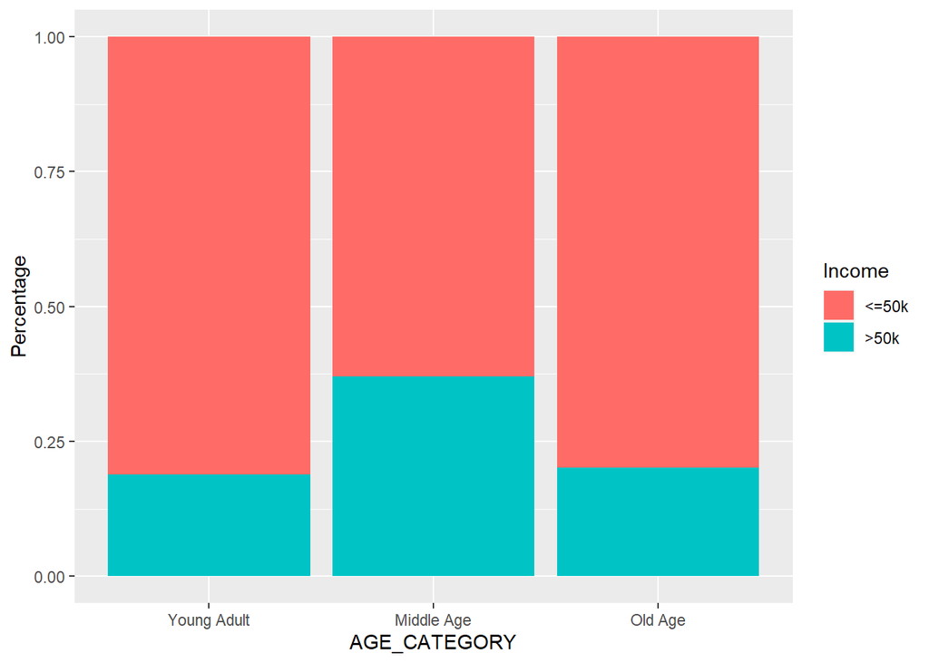

```r
one <- ggplot(data) +
  geom_bar(aes(x = AGE_CATEGORY, y = Percentage, fill = Income), position = "stack", stat = "identity") +
  scale_fill_manual(values = c("<=50k" = "#FF6C67", ">50k" = "#00C3C6"))

gridExtra::grid.arrange(one, nrow = 1)
```

2. Question: What conclusions do you draw about the dataset from the figure above?

Answer: The conclusions that I draw about the dataset from the figure (stacked bar plot) given in the assignment PDF is that the percentage of people earning an income above fifty thousand increases with increase in age. Therefore, income improves with age.

However, the conclusions that I draw about the dataset from the stacked bar plot created here is that the percentage of people earning an income above fifty thousand increases with increase in age until middle age, but it reduces again with old age showing that while income improves with age, people at old age tend to retire and begin living on their savings or lose their income stream some other way. All in all, the percentage of old people having their income above fifty thousand is more than the percentage of young adults having their income above fifty thousand.